# Bikes

## by Scott Smith

This data set includes information about individual rides made in a bike-sharing system covering the greater San Francisco Bay area.

```python
import numpy as np
import pandas as pd
import matplotlib.pyplot as plt
import seaborn as sb

%matplotlib inline

df = pd.read_csv('2017-fordgobike-tripdata.csv')
df_cleaned = df.dropna()
```

There were 519,700 records, but a lot of NaN's, so I cleaned up the file and now there are 453,159. There are 15 different characteristics about the ride and the riders.

1. The duration of the ride (how long are the customers using the bikes?)
2. Which gender rides more often? What age group rides most often?
3. Are they regular riders (subscriber) or just occasional (customer).

The main characteristics I will be investigating are - member gender, member birth year, user type and duration

There are 453,159 records after cleaning up the original data. There are 15 different characteristics about the ride and the riders.

The duration of the ride (how long are the customers using the bikes?)

Which gender rides more often? What age group rides most often?

Are they regular riders (subscriber) or just occasional (customer).

The main characteristics to be investigated are - member gender, member birth year, user type and duration.

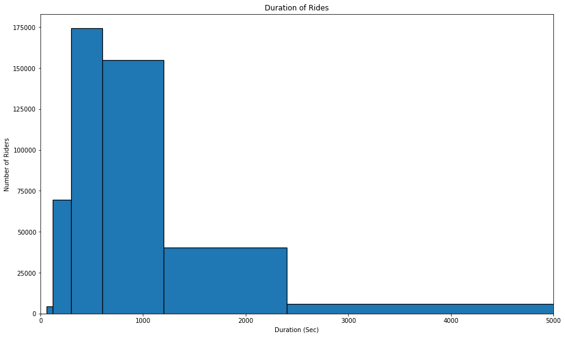

```python
x_values = [0, 60, 120, 300, 600, 1200, 2400, 6000, 10000]
#x_ticks = [round(x/60) for x in x_values]

plt.figure(figsize=[15, 9])
plt.hist(data = df_cleaned, x = 'duration_sec',  bins = x_values,
         edgecolor='black', linewidth=1.2)
plt.title('Duration of Rides')
plt.ylabel('Number of Riders')
plt.xlabel('Duration (Sec)')
#plt.xticks(x_values, x_ticks)
plt.xlim(0, 5000)
plt.show()
```

Because of the long tail to the right, I used a log scale.

Because the duration distribution shows a skew to the right, with a few rides of a very long duration, I used a log scale. Plotted with a log scale, it shows to be unimodel and peaking between 500 to 900 seconds (roughly 10 minute rides, about a 1/4 of the rides).

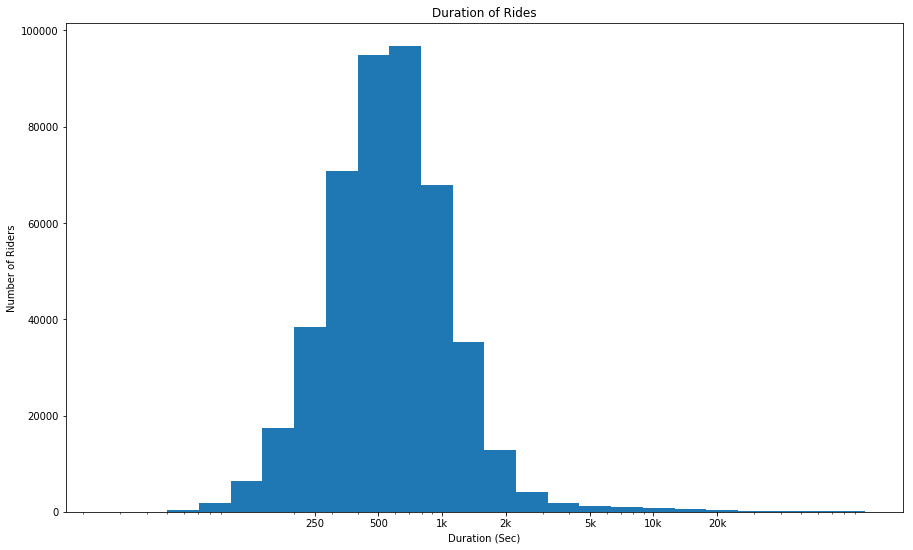

```python
log_binsize = .15
bins = 10 ** np.arange(1.4, np.log10(df_cleaned['duration_sec'].max())+log_binsize, log_binsize)

plt.figure(figsize=[15, 9])
plt.hist(data = df_cleaned, x = 'duration_sec', bins = bins)
plt.xscale('log')
plt.xticks([250, 500, 1e3, 2e3, 5e3, 1e4, 2e4], [250, 500, '1k', '2k', '5k', '10k', '20k'])
plt.title('Duration of Rides')
plt.ylabel('Number of Riders')
plt.xlabel('Duration (Sec)')
plt.show()
```

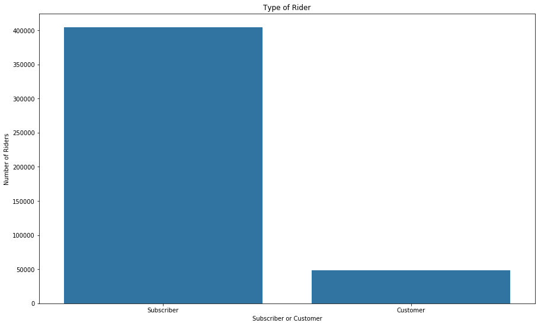

```python
base_color = sb.color_palette()[0]
plt.figure(figsize=[15, 9])
cat_order = df_cleaned['user_type'].value_counts().index
sb.countplot(data = df_cleaned, x = 'user_type', color = base_color, order = cat_order)
plt.title('Type of Rider')
plt.ylabel('Number of Riders')
plt.xlabel('Subscriber or Customer');
```

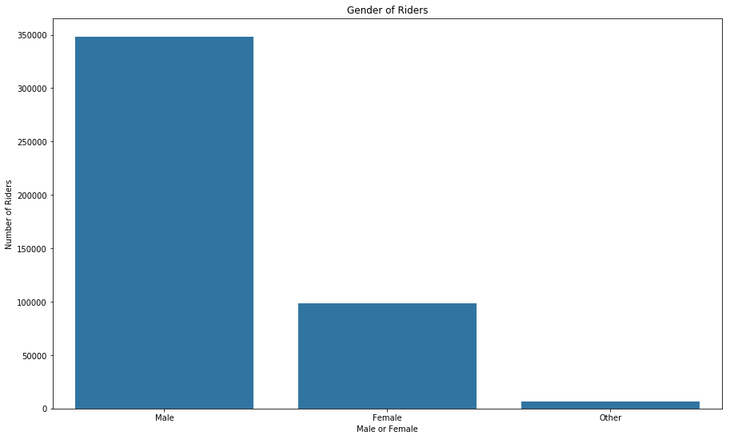

```python
base_color = sb.color_palette()[0]
plt.figure(figsize=[15, 9])
cat_order = df_cleaned['member_gender'].value_counts().index
sb.countplot(data = df_cleaned, x = 'member_gender', color = base_color, order = cat_order)
plt.title('Gender of Riders')
plt.ylabel('Number of Riders')
plt.xlabel('Male or Female');
```

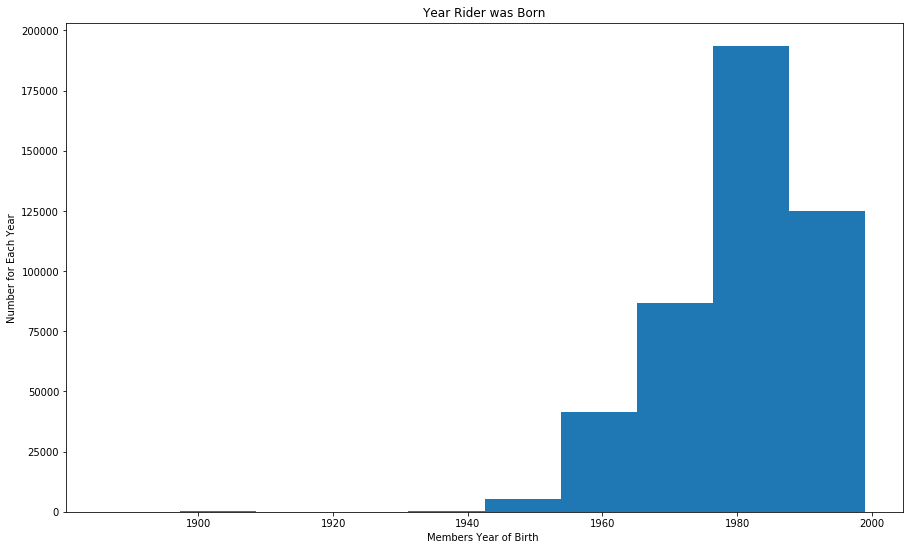

```python
plt.figure(figsize=[15, 9])
plt.hist(df_cleaned['member_birth_year'])
plt.title('Year Rider was Born')
plt.ylabel('Number for Each Year')
plt.xlabel('Members Year of Birth ');
```

The graph shows an overwhelming number of Subscribers as compared to the random Customer. The gender of the riders also shows that there are many more male riders than female or other riders.

I will now be using Bivariate plots to investigate the members gender in comparison to their birth year, as well as their gendr compared to rather they are subscribers or just a reagular customer. I will show how the age affected the duration of the rides.

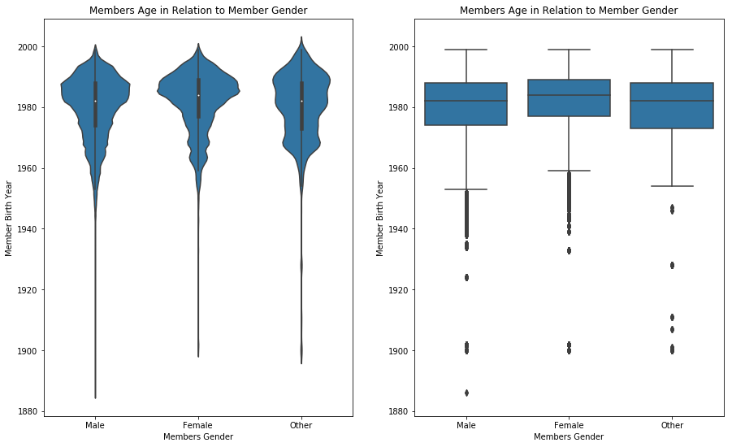

```python
plt.figure(figsize=[15, 9])
base_color = sb.color_palette()[0]

plt.subplot(1, 2, 1)
plt.title('Members Age in Relation to Member Gender')
ax1 = sb.violinplot(data = df_cleaned, x = 'member_gender', y = 'member_birth_year', color = base_color)
plt.xlabel('Members Gender')
plt.ylabel('Member Birth Year')

plt.subplot(1, 2, 2)
plt.title('Members Age in Relation to Member Gender')
sb.boxplot(data = df_cleaned, x = 'member_gender', y = 'member_birth_year', color = base_color)
plt.xlabel('Members Gender')
plt.ylabel('Member Birth Year')
plt.ylim(ax1.get_ylim()); # set y-axis limits to be same as left plot
```

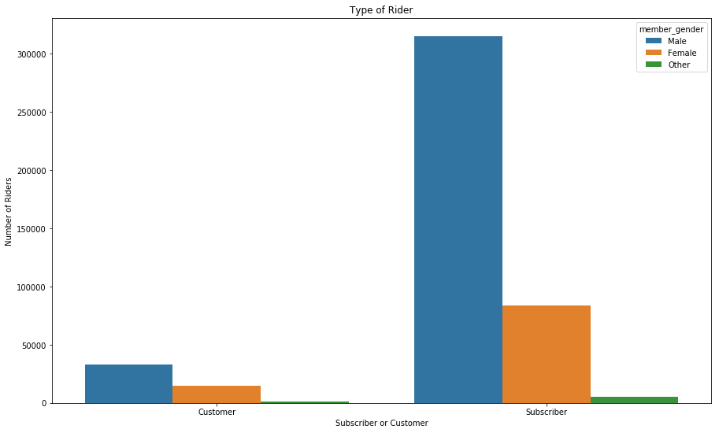

```python
plt.figure(figsize=[15, 9])
sb.countplot(data = df_cleaned, x = 'user_type', hue = 'member_gender')
plt.xlabel('Subscriber or Customer')
plt.ylabel('Number of Riders')
plt.title('Type of Rider');
```

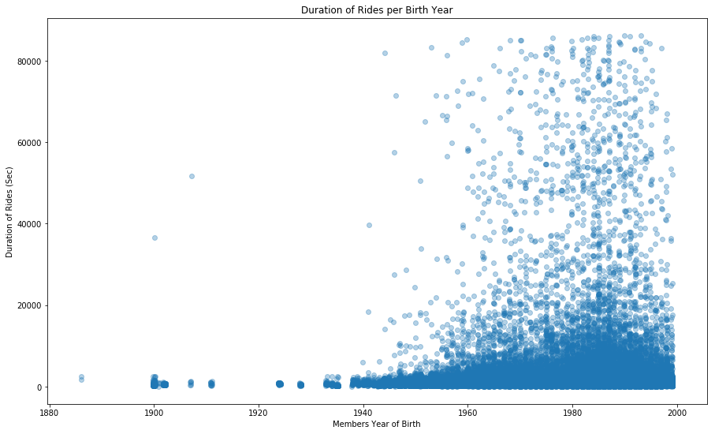

```python
plt.figure(figsize=[15, 9])
sb.regplot(data = df_cleaned, x = 'member_birth_year', y = 'duration_sec', fit_reg = False,
           x_jitter = 0.2, y_jitter = 0.2, scatter_kws = {'alpha' : 1/3})
plt.title('Duration of Rides per Birth Year')
plt.xlabel('Members Year of Birth')
plt.ylabel('Duration of Rides (Sec)');
```

The Multivariate plots will break down the age and gender groups into more detail with user type and duration of rides.

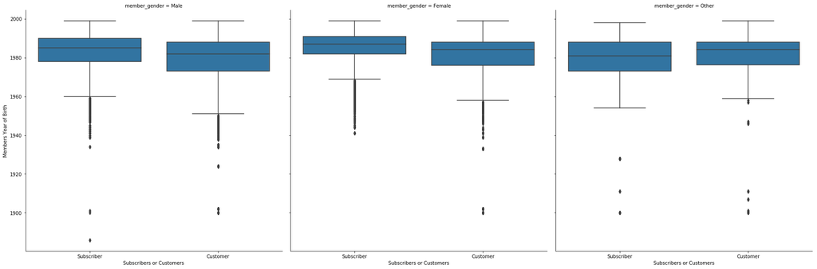

```python
g = sb.FacetGrid(data = df_cleaned, col = 'member_gender', size = 8)
g.map(sb.boxplot, 'user_type', 'member_birth_year')
g.set_xlabels('Subscribers or Customers')
g.set_ylabels('Members Year of Birth');
```

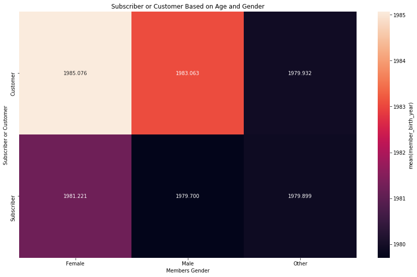

```python
cat_means = df.groupby(['member_gender', 'user_type']).mean()['member_birth_year']
cat_means = cat_means.reset_index(name = 'member_birth_year_avg')
cat_means = cat_means.pivot(index = 'user_type', columns = 'member_gender',
                            values = 'member_birth_year_avg')
plt.figure(figsize=[15, 9])
sb.heatmap(cat_means, annot = True, fmt = '.3f',
           cbar_kws = {'label' : 'mean(member_birth_year)'})
plt.xlabel('Members Gender')
plt.ylabel('Subscriber or Customer')
plt.title('Subscriber or Customer Based on Age and Gender');
```

While the majority of the birth years were early to mid 1980's, with early 1990's as the next level, there are considerably more male riders compared to female riders. The rides of longer duration; however, show a fairly even amount of males and females taking those longer rides.

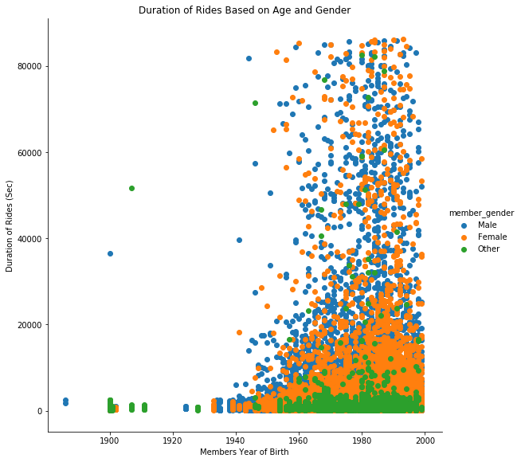

```python
g = sb.FacetGrid(data = df_cleaned, hue = 'member_gender', size = 8)
g.map(plt.scatter, 'member_birth_year','duration_sec')
g.set_xlabels('Members Year of Birth')
g.set_ylabels('Duration of Rides (Sec)')
plt.title('Duration of Rides Based on Age and Gender')
g.add_legend();
```

The plots show that the mean age of the subscribers for both male and females is older than the mean for the regular customers, while in the other group they are the same age. The overall age of the females is younger than both of the other groups. The scatterplot reinforces the majority of rides fall into the 20000 or less sec.

While there are considerably more male riders to female, the longer duration rides show a fairly even amount of males and females taking the longer rides.